# Analiza jakości zajęć na Wydziale Z-Nauk

Semestr 2022–2023/lato

Komisja ds. jakości kształcenia

01/01/2024

## Opis procedury zbierania i analizy danych

Ankieta oceniająca jakość studiowania w PSW jest udostępniana studentom w systemie Wirtualny Dziekanat. Wypełnione ankiety są eksportowane do pliku w formacie CSV, a analiza statystyczna jest wykonywana za pomocą autorskiego programu (w języku R) stworzonego przez członków zespołu d/s analizy jakości. **Dzięki zautomatyzowaniu przetwarzania danych (w miejsce używania do tego celu oprogramowania biurowego) udało się znacząco obniżyć koszty, zmniejszyć liczbę błędów oraz zapewnić 100% powtarzalność analiz**.

Wyżej wspomniana ankieta zawiera 9 zmiennych oceniających jakość zajęć prowadzone na PSW: `o1` – Sposób przedstawienia treści zajęć; `o2` – Wykorzystanie czasu zajęć; `o3` – Przedstawienie warunków uzyskania zaliczenia; `o4` – Kompetencje merytoryczne wykładowcy do prowadzenia zajęć; `o5` – Postawa wykładowcy wobec studentów; `o6` – Dostępność wykładowcy dla studentów; `o7` – Właściwy dobór zagadnień znacząco poszerzył moją wiedzę i umiejętności; `o8` – Sposób prowadzenia zajęć umożliwiał łączenie własnej wiedzy i doświadczeń z nową wiedzą i umiejętnościami; `o9` – Sposób prowadzenia zajęć umożliwiał rozwój kompetencji społecznych. Na każde pytanie możliwa było odpowiedź od bardzo źle do bardzo dobrze. Ponadto pytanie `o10` ocenia stopień zainteresowania studenta zajęciami (w skali od *uważam za bardzo mało interesujący* do *uważam za bardzo interesujący*)

Formularz ankiety znajduje się w Załączniku.

## Analiza wstępna danych

Łączna zebrano 11878 ankiet. Zestawienie w podziale na liczbę ankiet wg lat studiów zamieszczono w poniższej tabeli.

| rok | liczba ankiet |
| --- | --- |
| 0 | 183 |
| 1 | 8998 |
| 2 | 2539 |
| 3 | 158 |

Umownie rok `0` oznacza respondentów Pielęgniarstwa w ramach studiów pomostowych (PP).

Zestawienie w podziale na liczbę ankiet wg miejsca studiowania zamieszczono w poniższej tabeli.

| miejsce | liczba ankiet |
| --- | --- |
| GDA | 4231 |
| KOS | 1490 |
| KWI | 5956 |
| TOR | 201 |

Zestawienie w podziale na liczbę ankiet wg zajęć i ich typów zamieszczono w kolejnej tabeli.

**Uwaga**: w poniższych tabelach typ zajęć oraz nazwę przedmiotu zastąpiono skrótami. Typ zajęć: wykład (w), ćwiczenia (c), ćwiczenia symulacji (c), Lektorat (l), Samokształcenie (s), Zajęcia praktyczne (z), Praktyka (p), Seminarium (s). Zestawienie nazw przedmiotów zawiera zaś punkt **zestawienie przedmiotów**.

| prowadzący | typ | przedmiot | liczba ankiet |
| --- | --- | --- | --- |
| Wykładowca-002 | c | P018 | 81 |
| Wykładowca-003 | c | P010 | 127 |
| Wykładowca-003 | c | P019 | 81 |
| Wykładowca-003 | z | P039 | 8 |
| Wykładowca-004 | c | P030 | 8 |
| Wykładowca-005 | w | P007 | 283 |
| Wykładowca-005 | w | P031 | 121 |
| Wykładowca-005 | z | P021 | 5 |
| Wykładowca-006 | w | P043 | 8 |
| Wykładowca-006 | z | P021 | 13 |
| Wykładowca-007 | c | P009 | 99 |
| Wykładowca-007 | c | P021 | 11 |
| Wykładowca-007 | c | P033 | 18 |
| Wykładowca-008 | c | P004 | 190 |
| Wykładowca-009 | c | P024 | 160 |
| Wykładowca-010 | z | P006 | 47 |
| Wykładowca-011 | c | P022 | 38 |
| Wykładowca-012 | c | P020 | 69 |
| Wykładowca-013 | p | P011 | 14 |
| Wykładowca-013 | p | P012 | 3 |
| Wykładowca-014 | c | P029 | 44 |
| Wykładowca-015 | w | P023 | 121 |
| Wykładowca-015 | w | P026 | 54 |
| Wykładowca-016 | c | P009 | 47 |
| Wykładowca-017 | c | P021 | 9 |
| Wykładowca-018 | c | P005 | 74 |
| Wykładowca-018 | l | P005 | 24 |
| Wykładowca-019 | z | P006 | 127 |
| Wykładowca-021 | w | P044 | 79 |
| Wykładowca-021 | w | P055 | 10 |

[output cut: 157 more lines]

## Szczegółowa ocena wykładowców

W 2022-2023/L na wydziale Z-Nauk oceniono 114 prowadzących zajęcia.

W 2022-2023/L na wydziale Z-Nauk przeciętne oceny według poszczególnych kryteriów zawiera poniższa tabela (pierwsza wiersz to odsetek wskazań dobrze/bardzo dobrze, druga to odsetek wskazań źle/bardzo źle):

| kryterium | o1 | o2 | o3 | o4 | o5 | o6 | o7 | o8 | o9 | o10 |
| --- | --- | --- | --- | --- | --- | --- | --- | --- | --- | --- |
| dobrze | 86.1 | 85.9 | 85.1 | 86.2 | 84.6 | 84.1 | 83.5 | 82.7 | 81.5 | 82.5 |
| źle | 4.0 | 3.6 | 4.6 | 3.2 | 4.7 | 4.4 | 3.5 | 3.5 | 3.7 | 1.8 |

Łączna ocena wykładowcy (dla każdego prowadzonego przedmiotu/typu przedmiotu osobno, określona jako odsetek wskazań dobry/bardzo dobry)

| prowadzący/liczba ankiet | o1 | o2 | o3 | o4 | o5 | o6 | o7 | o8 | o9 | o10 |
| --- | --- | --- | --- | --- | --- | --- | --- | --- | --- | --- |
| Wykładowca-002/81 | 82.7 | 85.2 | 85.2 | 84.0 | 85.2 | 86.4 | 79.0 | 79.0 | 75.3 | 76.5 |
| Wykładowca-003/216 | 90.7 | 90.3 | 90.3 | 90.3 | 88.9 | 90.7 | 89.4 | 89.8 | 88.4 | 87.0 |
| Wykładowca-004/8 | 100.0 | 100.0 | 100.0 | 100.0 | 100.0 | 100.0 | 100.0 | 100.0 | 100.0 | 100.0 |
| Wykładowca-005/409 | 89.2 | 89.7 | 90.2 | 89.0 | 90.5 | 89.7 | 86.8 | 85.8 | 85.3 | 85.6 |
| Wykładowca-006/21 | 100.0 | 100.0 | 100.0 | 95.2 | 95.2 | 95.2 | 95.2 | 95.2 | 95.2 | 95.2 |
| Wykładowca-007/128 | 89.8 | 90.6 | 88.3 | 89.1 | 88.3 | 89.1 | 85.9 | 85.9 | 85.9 | 85.9 |
| Wykładowca-008/190 | 92.6 | 92.1 | 92.6 | 92.6 | 93.2 | 92.6 | 90.5 | 89.5 | 87.9 | 88.4 |
| Wykładowca-009/160 | 74.4 | 73.1 | 76.2 | 72.5 | 70.6 | 70.0 | 70.0 | 68.8 | 68.1 | 67.5 |
| Wykładowca-010/47 | 100.0 | 100.0 | 100.0 | 100.0 | 100.0 | 100.0 | 95.7 | 95.7 | 95.7 | 95.7 |
| Wykładowca-011/38 | 84.2 | 84.2 | 81.6 | 81.6 | 86.8 | 81.6 | 81.6 | 78.9 | 71.1 | 78.9 |
| Wykładowca-012/69 | 95.7 | 94.2 | 95.7 | 95.7 | 95.7 | 95.7 | 91.3 | 91.3 | 88.4 | 91.3 |
| Wykładowca-013/17 | 82.4 | 82.4 | 88.2 | 82.4 | 88.2 | 88.2 | 82.4 | 82.4 | 88.2 | 82.4 |
| Wykładowca-014/44 | 90.9 | 90.9 | 90.9 | 90.9 | 88.6 | 88.6 | 84.1 | 81.8 | 84.1 | 79.5 |
| Wykładowca-015/175 | 78.3 | 77.1 | 75.4 | 77.1 | 77.7 | 75.4 | 72.0 | 68.0 | 68.0 | 65.1 |
| Wykładowca-016/47 | 93.6 | 89.4 | 95.7 | 93.6 | 91.5 | 91.5 | 91.5 | 87.2 | 89.4 | 87.2 |
| Wykładowca-017/9 | 88.9 | 88.9 | 88.9 | 88.9 | 88.9 | 88.9 | 88.9 | 88.9 | 88.9 | 88.9 |
| Wykładowca-018/98 | 65.3 | 66.3 | 72.4 | 67.3 | 67.3 | 67.3 | 64.3 | 64.3 | 62.2 | 62.2 |
| Wykładowca-019/127 | 88.2 | 88.2 | 88.2 | 88.2 | 88.2 | 87.4 | 84.3 | 85.0 | 85.0 | 82.7 |
| Wykładowca-021/89 | 84.3 | 84.3 | 85.4 | 83.1 | 85.4 | 82.0 | 88.8 | 86.5 | 79.8 | 87.6 |
| Wykładowca-023/126 | 88.1 | 85.7 | 87.3 | 86.5 | 86.5 | 85.7 | 82.5 | 81.7 | 84.1 | 83.3 |
| Wykładowca-024/338 | 72.2 | 72.2 | 69.5 | 72.5 | 66.0 | 67.2 | 68.3 | 66.6 | 65.1 | 65.7 |
| Wykładowca-025/25 | 100.0 | 100.0 | 100.0 | 100.0 | 100.0 | 100.0 | 100.0 | 100.0 | 100.0 | 100.0 |
| Wykładowca-026/50 | 90.0 | 90.0 | 90.0 | 90.0 | 90.0 | 90.0 | 88.0 | 88.0 | 86.0 | 84.0 |
| Wykładowca-027/10 | 100.0 | 100.0 | 100.0 | 100.0 | 100.0 | 100.0 | 100.0 | 100.0 | 100.0 | 100.0 |
| Wykładowca-030/286 | 31.1 | 30.1 | 24.8 | 31.5 | 24.8 | 25.2 | 28.0 | 27.6 | 28.7 | 35.0 |
| Wykładowca-031/10 | 80.0 | 80.0 | 100.0 | 100.0 | 100.0 | 100.0 | 100.0 | 100.0 | 90.0 | 100.0 |
| Wykładowca-032/180 | 95.6 | 96.1 | 96.1 | 96.1 | 95.6 | 95.0 | 93.3 | 93.9 | 93.9 | 93.9 |
| Wykładowca-033/331 | 85.2 | 85.2 | 81.6 | 86.4 | 78.5 | 80.1 | 81.6 | 81.0 | 79.8 | 77.6 |
| Wykładowca-034/62 | 98.4 | 98.4 | 95.2 | 96.8 | 96.8 | 95.2 | 93.5 | 95.2 | 93.5 | 93.5 |
| Wykładowca-036/81 | 96.3 | 93.8 | 95.1 | 93.8 | 93.8 | 93.8 | 92.6 | 92.6 | 91.4 | 92.6 |

[output cut: 84 more lines]

Szczegółowe oceny wykładowców (dla każdego prowadzonego przedmiotu/typu przedmiotu osobno, określona jako odsetek wskazań dobry/bardzo dobry)

| prowadzący | przedmiot | N | o1 | o2 | o3 | o4 | o5 | o6 | o7 | o8 | o9 | o10 |
| --- | --- | --- | --- | --- | --- | --- | --- | --- | --- | --- | --- | --- |
| Wykładowca-002 | P018/c | 81 | 82.7 | 85.2 | 85.2 | 84.0 | 85.2 | 86.4 | 79.0 | 79.0 | 75.3 | 76.5 |
| Wykładowca-003 | P010/c | 127 | 89.8 | 89.8 | 91.3 | 89.8 | 89.0 | 90.6 | 89.0 | 89.8 | 88.2 | 87.4 |
| Wykładowca-003 | P019/c | 81 | 91.4 | 90.1 | 87.7 | 90.1 | 87.7 | 90.1 | 88.9 | 88.9 | 87.7 | 85.2 |
| Wykładowca-003 | P039/z | 8 | 100.0 | 100.0 | 100.0 | 100.0 | 100.0 | 100.0 | 100.0 | 100.0 | 100.0 | 100.0 |
| Wykładowca-004 | P030/c | 8 | 100.0 | 100.0 | 100.0 | 100.0 | 100.0 | 100.0 | 100.0 | 100.0 | 100.0 | 100.0 |
| Wykładowca-005 | P007/w | 283 | 89.8 | 90.1 | 90.5 | 89.0 | 90.8 | 90.5 | 88.0 | 86.9 | 86.2 | 86.6 |
| Wykładowca-005 | P021/z | 5 | 100.0 | 100.0 | 100.0 | 100.0 | 100.0 | 100.0 | 100.0 | 100.0 | 100.0 | 100.0 |
| Wykładowca-005 | P031/w | 121 | 87.6 | 88.4 | 89.3 | 88.4 | 89.3 | 87.6 | 83.5 | 82.6 | 82.6 | 82.6 |
| Wykładowca-006 | P021/z | 13 | 100.0 | 100.0 | 100.0 | 92.3 | 92.3 | 92.3 | 92.3 | 92.3 | 92.3 | 92.3 |
| Wykładowca-006 | P043/w | 8 | 100.0 | 100.0 | 100.0 | 100.0 | 100.0 | 100.0 | 100.0 | 100.0 | 100.0 | 100.0 |
| Wykładowca-007 | P009/c | 99 | 88.9 | 89.9 | 86.9 | 87.9 | 86.9 | 86.9 | 84.8 | 84.8 | 85.9 | 84.8 |
| Wykładowca-007 | P021/c | 11 | 90.9 | 90.9 | 90.9 | 90.9 | 90.9 | 90.9 | 90.9 | 90.9 | 90.9 | 90.9 |
| Wykładowca-007 | P033/c | 18 | 94.4 | 94.4 | 94.4 | 94.4 | 94.4 | 100.0 | 88.9 | 88.9 | 83.3 | 88.9 |
| Wykładowca-008 | P004/c | 190 | 92.6 | 92.1 | 92.6 | 92.6 | 93.2 | 92.6 | 90.5 | 89.5 | 87.9 | 88.4 |
| Wykładowca-009 | P024/c | 160 | 74.4 | 73.1 | 76.2 | 72.5 | 70.6 | 70.0 | 70.0 | 68.8 | 68.1 | 67.5 |
| Wykładowca-010 | P006/z | 47 | 100.0 | 100.0 | 100.0 | 100.0 | 100.0 | 100.0 | 95.7 | 95.7 | 95.7 | 95.7 |
| Wykładowca-011 | P022/c | 38 | 84.2 | 84.2 | 81.6 | 81.6 | 86.8 | 81.6 | 81.6 | 78.9 | 71.1 | 78.9 |
| Wykładowca-012 | P020/c | 69 | 95.7 | 94.2 | 95.7 | 95.7 | 95.7 | 95.7 | 91.3 | 91.3 | 88.4 | 91.3 |
| Wykładowca-013 | P011/p | 14 | 78.6 | 78.6 | 85.7 | 78.6 | 85.7 | 85.7 | 78.6 | 78.6 | 85.7 | 78.6 |
| Wykładowca-013 | P012/p | 3 | 100.0 | 100.0 | 100.0 | 100.0 | 100.0 | 100.0 | 100.0 | 100.0 | 100.0 | 100.0 |
| Wykładowca-014 | P029/c | 44 | 90.9 | 90.9 | 90.9 | 90.9 | 88.6 | 88.6 | 84.1 | 81.8 | 84.1 | 79.5 |
| Wykładowca-015 | P023/w | 121 | 73.6 | 72.7 | 71.9 | 72.7 | 72.7 | 71.9 | 66.1 | 64.5 | 65.3 | 61.2 |
| Wykładowca-015 | P026/w | 54 | 88.9 | 87.0 | 83.3 | 87.0 | 88.9 | 83.3 | 85.2 | 75.9 | 74.1 | 74.1 |
| Wykładowca-016 | P009/c | 47 | 93.6 | 89.4 | 95.7 | 93.6 | 91.5 | 91.5 | 91.5 | 87.2 | 89.4 | 87.2 |
| Wykładowca-017 | P021/c | 9 | 88.9 | 88.9 | 88.9 | 88.9 | 88.9 | 88.9 | 88.9 | 88.9 | 88.9 | 88.9 |
| Wykładowca-018 | P005/c | 74 | 59.5 | 60.8 | 68.9 | 62.2 | 62.2 | 62.2 | 59.5 | 59.5 | 58.1 | 59.5 |
| Wykładowca-018 | P005/l | 24 | 83.3 | 83.3 | 83.3 | 83.3 | 83.3 | 83.3 | 79.2 | 79.2 | 75.0 | 70.8 |
| Wykładowca-019 | P006/z | 127 | 88.2 | 88.2 | 88.2 | 88.2 | 88.2 | 87.4 | 84.3 | 85.0 | 85.0 | 82.7 |
| Wykładowca-021 | P044/w | 79 | 83.5 | 83.5 | 84.8 | 82.3 | 84.8 | 81.0 | 87.3 | 84.8 | 78.5 | 86.1 |
| Wykładowca-021 | P055/w | 10 | 90.0 | 90.0 | 90.0 | 90.0 | 90.0 | 90.0 | 100.0 | 100.0 | 90.0 | 100.0 |

[output cut: 157 more lines]

## Zestawienie przedmiotów

| przedmiot | id |
| --- | --- |
| Coaching w pielęgniarstwie | P001 |
| Opieka i edukacja terapeutyczna w chorobach przewlekłych: choroba nowotworowa leczenie żywieniowe | P002 |
| Opieka i edukacja terapeutyczna w chorobach przewlekłych: zaburzenia zdrowia psychicznego | P003 |
| Prawo w praktyce pielęgniarskiej | P004 |
| Język obcy - język angielski | P005 |
| Opieka i edukacja terapeutyczna w chorobach przewlekłych: leczenie nerkozastępcze | P006 |
| Opieka i edukacja terapeutyczna w chorobach przewlekłych: cukrzyca | P007 |
| Seminarium magisterskie | P008 |
| Opieka i edukacja terapeutyczna w chorobach przewlekłych: rany przewlekłe i przetoki | P009 |
| Opieka i edukacja terapeutyczna w chorobach przewlekłych: zaburzenia układu nerwowego | P010 |
| Podstawowa Opieka Zdrowotna | P011 |
| Zarządzanie w pielęgniarstwie | P012 |
| Seminarium magisterskie przygotowanie pracy magisterskiej przygotowanie do egzaminu do egzaminu dyplomowego | P013 |
| Pielęgniarstwo wielokulturowe | P014 |
| Endoskopia | P015 |
| Fizjologia | P016 |
| Patologia | P017 |
| Radiologia | P018 |
| Współpraca w zespołach opieki zdrowotnej | P019 |
| Organizacja pracy pielęgniarskiej | P020 |
| Podstawy pielęgniarstwa | P021 |
| Farmakologia | P022 |
| WDW Marketing w internecie | P023 |
| Psychologia | P024 |
| Dietetyka | P025 |
| WDW Tworzenie biznesplanu | P026 |
| WDW Rola mediów we współczesnym świecie | P027 |
| WDW Komunikacja w biznesie | P028 |
| Wychowanie fizyczne | P029 |
| Chirurgia i pielęgniarstwo chirurgiczne | P030 |
| Promocja zdrowia | P031 |
| Położnictwo ginekologia i pielęgniarstwo położniczo - ginekologiczne | P032 |
| Badania naukowe w pielęgniarstwie | P033 |
| Podstawowa opieka zdrowotna Medycyna przedszkolna | P034 |
| Psychiatria i pielęgniarstwo psychiatryczne | P035 |
| Seminarium dyplomowe | P036 |
| Pielęgniarstwo w opiece długoterminowej | P037 |
| Podstawy rehabilitacji | P038 |
| Neurologia i pielęgniarstwo neurologiczne | P039 |
| Przygotowanie do egzaminu dyplomowego | P040 |
| Anestezjologia i pielęgniarstwo w zagrożeniu życia | P041 |
| Opieka paliatywna | P042 |
| Choroby wewnętrzne i pielęgniarstwo internistyczne | P043 |
| Podstawowe zabiegi medyczne | P044 |
| Fizjologia z elementami fizjologii klinicznej | P045 |
| Dydaktyka medyczna | P046 |
| Techniki zabiegów medycznych | P047 |
| Etyka zawodowa ratownika medycznego | P048 |
| Medyczne czynności ratunkowe (ALS PALS ATLS) | P049 |
| Chirurgia | P050 |
| Zajęcia sprawnościowe z elementami ratownictwa specjalistycznego: ratownictwo wodne | P051 |
| Położnictwo i ginekologia | P052 |
| Medycyna ratunkowa | P053 |
| Intensywna terapia | P054 |
| Medycyna taktyczna | P055 |
| Komunikacja interpersonalna Ratownik medyczny - pacjent | P056 |
| Neurochirurgia | P057 |
| Medycyna sądowa | P058 |
| Okulistyka | P059 |
| Laryngologia | P060 |

## Zbiorcza ocena zajęć

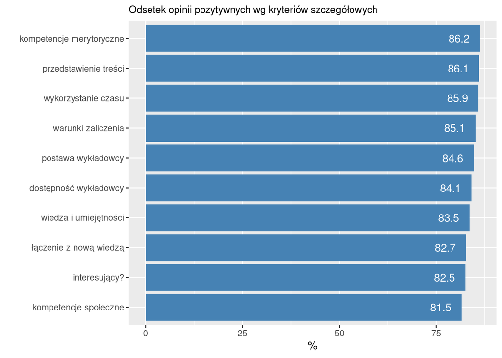

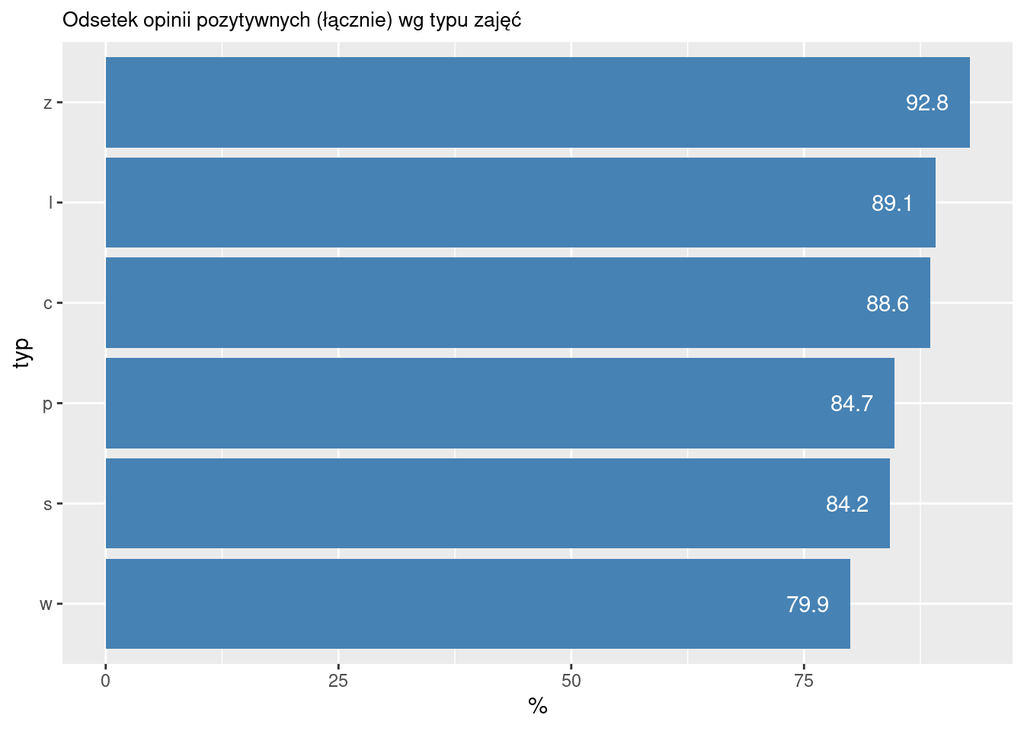

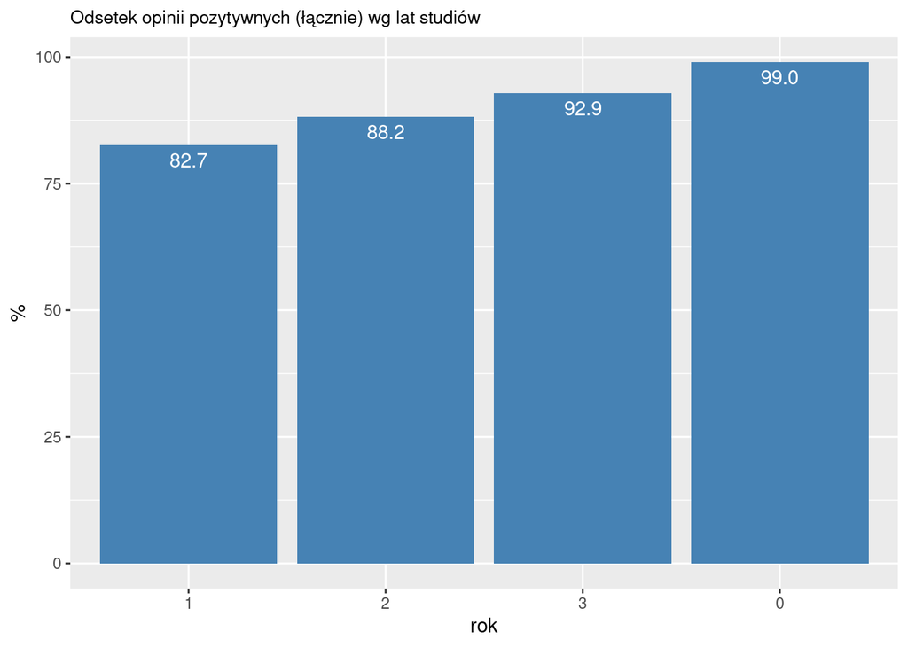

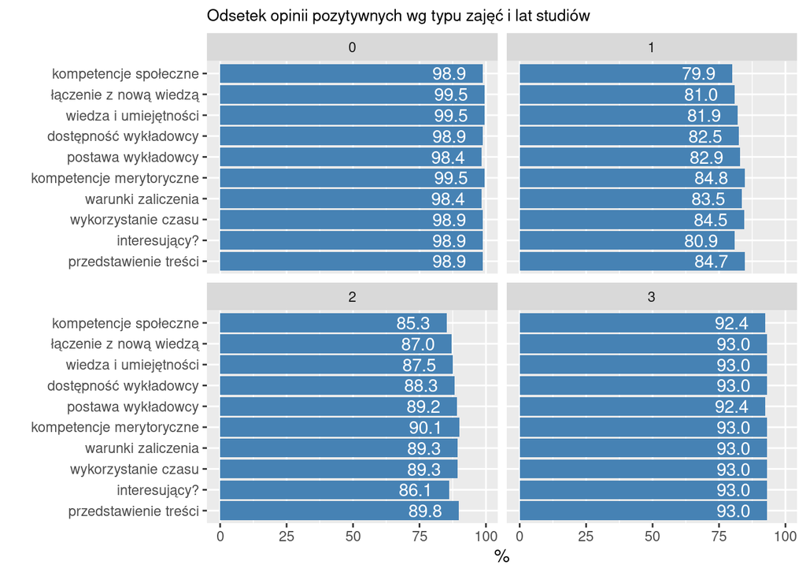

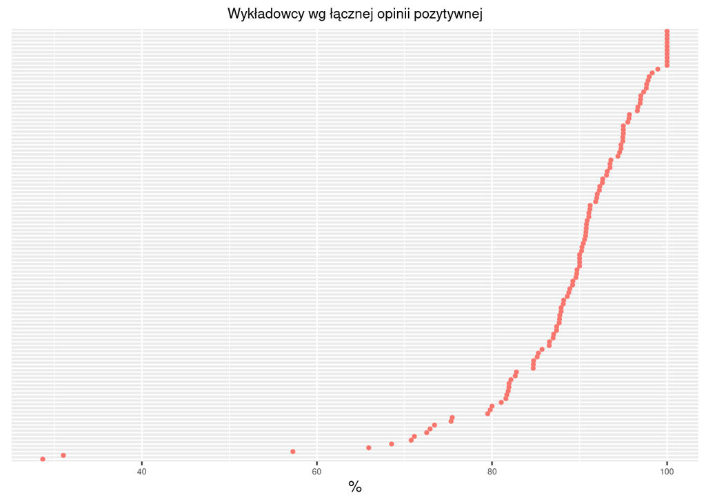

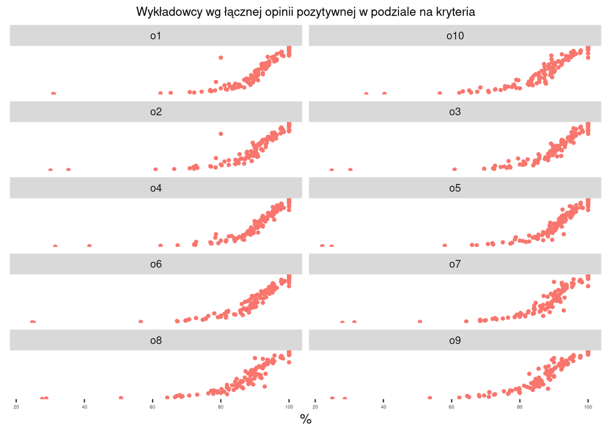

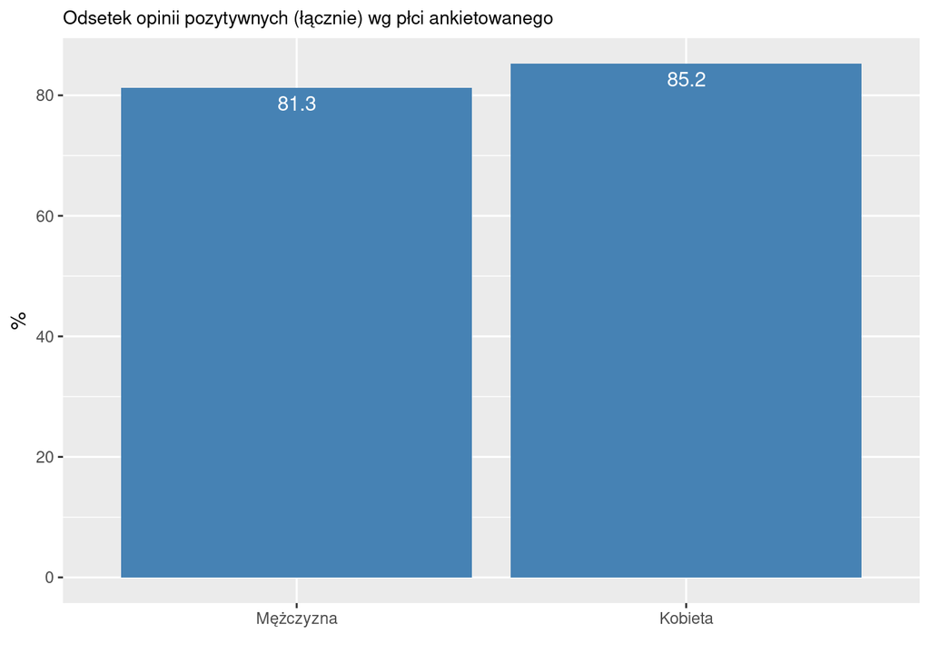

## Formularz ankiety oceny jakości zajęć

1. Nazwa przedmiotu
2. Imię i nazwisko wykładowcy
3. Forma zajęć

Proszę o ocenę zajęć pod względem następujących kryteriów (Odpowiedzi na pytania 4–12 w skali: ** [] zdecydowanie się nie zgadzam [] nie zgadzam się [] ani się zgadzam ani się nie zgadzam [] zgadzam się [] zdecydowanie się zgadzam**; pytanie 13 w skali:** uważam za bardzo mało interesujący [] uważam za mało interesujący [] nie mam zdania [] uważam za interesujący [] uważam za bardzo interesujący**)

4. Jak Pan/Pani ocenia sposób przedstawienia treści zajęć
5. Jak Pan/Pani ocenia wykorzystanie czasu pracy
6. Jak Pan/Pani ocenia przedstawienie warunków uzyskania zaliczenia
7. Jak Pan/Pani ocenia kompetencje merytoryczne wykładowcy do prowadzenia zajęć
8. Jak Pan/Pani ocenia postawę wykładowcy wobec studentów
9. Jak Pan/Pani ocenia dostępność wykładowcy dla studentów
10. W mojej opinii zajęcia poszerzyły moją wiedzę i umiejętności
11. W mojej opinii zajęcia umożliwiły łączenie mojej wiedzy i doświadczeń z nową wiedzą i umiejętnościami
12. W mojej opinii zajęcia rozwinęły moje kompetencjie społeczne
13. Czy uważa Pani/Pan przedmiot zajęć za interesujący i warty poznania czy raczej Pani/Pan bierze udział w zajęciach żeby uzyskać zaliczenie
14. Rok studiów
15. Tryb [] stacjonarne [] niestacjonarne
16. Kierunek: [] Ekonomia [] Pielęgniarstwo [] Pielęgniarstwo pomostowe [] Ratownictwo medyczne [] Kosmetologia
17. Płeć [] kobieta [] mężczyna
18. Miejsce studiowania [] Kwidzyn [] Filia Gdańsk